# Dunnhumby Case

Jacqueline Berracasa

3/26/2019

### Reading and Preparing the Data

```r
library(readr)
library(tidyverse)
causal <- read_csv("dh_causal_lookup.csv")
product <- read_csv("dh_product_lookup.csv")
store <- read_csv("dh_store_lookup.csv")
transactions <- read_csv("dh_transactions.csv")
product$commodity <- as.factor(product$commodity)
transactions$upc <- as.numeric(transactions$upc)
```

## Question A

```r
prod_trans <- transactions %>% left_join(product, by="upc")

#levels(product$commodity)

#pancake mixes
top5_pancake <- prod_trans %>%
  filter(commodity == "pancake mixes") %>%
  group_by(upc) %>%
  summarise(sum=sum(dollar_sales)) %>%
  arrange(desc(sum)) %>%
  head(5)

top5_pancake
```

```
## # A tibble: 5 x 2
##          upc    sum
##        <dbl>  <dbl>
## 1 3000005300 93321.
## 2 3000005040 55975.
## 3 3000005070 50030.
## 4 9999985261 44962.
## 5 1800028064 44005.
```

```r
upc1 <- prod_trans %>% filter(upc==top5_pancake$upc[[1]]) %>% select(product_description, brand, product_size)
upc2 <- prod_trans %>% filter(upc==top5_pancake$upc[[2]]) %>% select(product_description, brand, product_size)
upc3 <- prod_trans %>% filter(upc==top5_pancake$upc[[3]]) %>% select(product_description, brand, product_size)
upc4 <- prod_trans %>% filter(upc==top5_pancake$upc[[4]]) %>% select(product_description, brand, product_size)
upc5 <- prod_trans %>% filter(upc==top5_pancake$upc[[5]]) %>% select(product_description, brand, product_size)
df_pancake <- rbind(upc1[1,],upc2[1,],upc3[1,],upc4[1,],upc5[1,])
df_pancake
```

```
## # A tibble: 5 x 3
##   product_description                brand         product_size
##   <chr>                              <chr>         <chr>
## 1 AJ BUTTERMILK PANCAKE MIX          Aunt Jemima   32 OZ
## 2 AUNT JEM ORIGINAL PANCAKE MIX      Aunt Jemima   2 LB
## 3 A/JEM COMPLETE PANCAKE MI          Aunt Jemima   32    OZ
## 4 PRIVATE LABEL COMPLETE PANCAKE MIX Private Label 2 LB
## 5 H J PANCK BTRMLK COMP MIX          Hungry Jack   <NA>
```

```r
#pasta
top5_pasta <- prod_trans %>%
  filter(commodity == "pasta") %>%
  group_by(upc) %>%
  summarise(sum=sum(dollar_sales)) %>%
  arrange(desc(sum)) %>%
  head(5)

upc_p1 <- prod_trans %>% filter(upc==top5_pasta$upc[[1]]) %>% select(product_description, brand, product_size)
upc_p2 <-prod_trans %>% filter(upc==top5_pasta$upc[[2]]) %>% select(product_description, brand, product_size)
upc_p3 <-prod_trans %>% filter(upc==top5_pasta$upc[[3]]) %>% select(product_description, brand, product_size)
upc_p4 <-prod_trans %>% filter(upc==top5_pasta$upc[[4]]) %>% select(product_description, brand, product_size)
upc_p5 <-prod_trans %>% filter(upc==top5_pasta$upc[[5]]) %>% select(product_description, brand, product_size)
df_pasta <- rbind(upc_p1[1,],upc_p2[1,],upc_p3[1,],upc_p4[1,],upc_p5[1,])
df_pasta
```

```
## # A tibble: 5 x 3
##   product_description             brand         product_size
##   <chr>                           <chr>         <chr>
## 1 PRIVATE LABEL THIN SPAGHETTI    Private Label 16 OZ
## 2 PRIVATE LABEL SPAGHETTI REGULAR Private Label 16 OZ
## 3 PRIVATE LABEL ANGEL HAIR PASTA  Private Label 16 OZ
## 4 PRIVATE LABEL SPAGHETTI THIN    Private Label 32OZ
## 5 PRIVATE LABEL SPAGHETTI REGULAR Private Label 32OZ
```

```r
#pasta sauce
top5_pastas <- prod_trans %>%
  filter(commodity == "pasta sauce") %>%
  group_by(upc) %>%
  summarise(sum=sum(dollar_sales)) %>%
  arrange(desc(sum)) %>%
  head(5)
top5_pastas
```

```
## # A tibble: 5 x 2
##          upc     sum
##        <dbl>   <dbl>
## 1 3620000250 146472.
## 2 5100002549 115525.
## 3 3620000300  89174.
## 4 3620001401  80414.
## 5 3620001369  79490.
```

```r
upcps1 <- prod_trans %>% filter(upc==top5_pastas$upc[[1]]) %>% select(product_description, brand, product_size)
upcps2 <- prod_trans %>% filter(upc==top5_pastas$upc[[2]]) %>% select(product_description, brand, product_size)
upcps3 <- prod_trans %>% filter(upc==top5_pastas$upc[[3]]) %>% select(product_description, brand, product_size)
upcps4 <- prod_trans %>% filter(upc==top5_pastas$upc[[4]]) %>% select(product_description, brand, product_size)
upcps5 <- prod_trans %>% filter(upc==top5_pastas$upc[[5]]) %>% select(product_description, brand, product_size)

df_pastas <- rbind(upcps1[1,],upcps2[1,],upcps3[1,],upcps4[1,],upcps5[1,])
df_pastas
```

```
## # A tibble: 5 x 3
##   product_description         brand product_size
##   <chr>                       <chr> <chr>
## 1 RAGU TRADITIONAL PLAIN      Ragu  26 OZ
## 2 PREGO REG SPAGHETTI SAUCE   Prego 26 OZ
## 3 RAGU OWS SPAG SAUCE MEAT    Ragu  26 OZ
## 4 RAGU SPAGH SAUCE PLAIN      Ragu  45 OZ
## 5 "RAGU\\CHZ CREATION ALFRDO" Ragu  16 OZ
```

```r
#syrups
top5_syrup <- prod_trans %>%
  filter(commodity == "syrups") %>%
  group_by(upc) %>%
  summarise(sum=sum(dollar_sales)) %>%
  arrange(desc(sum)) %>%
  head(5)

top5_syrup
```

```
## # A tibble: 5 x 2
##          upc    sum
##        <dbl>  <dbl>
## 1 3000005970 98923.
## 2 9999967727 96147.
## 3 4420979129 86814.
## 4 9999981816 66622.
## 5 9999966070 62945.
```

```r
upcs1 <- prod_trans %>% filter(upc==top5_syrup$upc[[1]]) %>% select(product_description, brand, product_size)
upcs2 <- prod_trans %>% filter(upc==top5_syrup$upc[[2]]) %>% select(product_description, brand, product_size)
upcs3 <- prod_trans %>% filter(upc==top5_syrup$upc[[3]]) %>% select(product_description, brand, product_size)
upcs4 <- prod_trans %>% filter(upc==top5_syrup$upc[[4]]) %>% select(product_description, brand, product_size)
upcs5 <- prod_trans %>% filter(upc==top5_syrup$upc[[5]]) %>% select(product_description, brand, product_size)

df_syrup <- rbind(upcs1[1,],upcs2[1,],upcs3[1,],upcs4[1,],upcs5[1,])
df_syrup
```

```
## # A tibble: 5 x 3
##   product_description                brand                 product_size
##   <chr>                              <chr>                 <chr>
## 1 AUNT JEMIMA ORIGINL SYRUP          Aunt Jemima           24 OZ
## 2 PRIVATE LABEL SYRUP PLASTIC BOTTLE Private Label         24 OZ
## 3 MRS BUTTERWORTH SYRUP              Mrs Butterworth       24 OZ
## 4 PRIVATE LABEL MAPLE SYRUP          Private Label Premium 12 OZ
## 5 PRIVATE LABEL BUTTERED SYRUP       Private Label         P    24 OZ
```

Pancake: Aunt Jemima (top 3) Pasta: Private Label (no variety) Pasta Sauce: Ragu and Prego (mostly Ragu) Pancake Syrup: Aunt Jemima, private label, Mrs Butterworth (more variety)

## Question B

```r
#pancake mixes
top5_pancakeb <- prod_trans %>%
  filter(commodity == "pancake mixes") %>%
  group_by(brand) %>%
  summarise(sum=sum(dollar_sales)) %>%
  arrange(desc(sum)) %>%
  head(5)
top5_pancakeb
```

```
## # A tibble: 5 x 2
##   brand             sum
##   <chr>           <dbl>
## 1 Aunt Jemima   206698.
## 2 Hungry Jack   111435.
## 3 Private Label  73617.
## 4 Krusteaz       30529.
## 5 Bisquick       18438.
```

```r
#pasta
top5_pastab <- prod_trans %>%
  filter(commodity == "pasta") %>%
  group_by(brand) %>%
  summarise(sum=sum(dollar_sales)) %>%
  arrange(desc(sum)) %>%
  head(5)
top5_pastab
```

```
## # A tibble: 5 x 2
##   brand             sum
##   <chr>           <dbl>
## 1 Private Label 995201.
## 2 Barilla       433765.
## 3 Creamette     271543.
## 4 Mueller       270701.
## 5 Ronzoni       213566.
```

```r
#pasta sauce
top5_pastasb <- prod_trans %>%
  filter(commodity == "pasta sauce") %>%
  group_by(brand) %>%
  summarise(sum=sum(dollar_sales)) %>%
  arrange(desc(sum)) %>%
  head(5)
top5_pastasb
```

```
## # A tibble: 5 x 2
##   brand              sum
##   <chr>            <dbl>
## 1 Ragu          1500755.
## 2 Prego          799932.
## 3 Classico       438178.
## 4 Private Label  331062.
## 5 Bertolli       258091.
```

```r
#syrups
top5_syrupb <- prod_trans %>%
  filter(commodity == "syrups") %>%
  group_by(brand) %>%
  summarise(sum=sum(dollar_sales)) %>%
  arrange(desc(sum)) %>%
  head(5)
top5_syrupb
```

```
## # A tibble: 5 x 2
##   brand               sum
##   <chr>             <dbl>
## 1 Aunt Jemima     359669.
## 2 Private Label   352931.
## 3 Mrs Butterworth 159165.
## 4 Log Cabin       130904.
## 5 Karo            120431.
```

All commodities have much more variety by brand than by product.

Additional things to explore: does this grocery store have a generic/store brand? Why isn’t that brand doing as well? I would think that it would be in the grocery store’s best interests to sell a lot of their own brand.

## Question C

```r
#join on zip code
library(zipcode)
data("zipcode")
prod_trans <- prod_trans %>% left_join(store, by ="store")

#these brands drive sales:
prod_trans %>%
  filter(commodity == "pasta") %>%
  group_by(brand) %>%
  summarise(sum=sum(dollar_sales)) %>%
  arrange(desc(sum)) %>%
  head(5)
```

```
## # A tibble: 5 x 2
##   brand             sum
##   <chr>           <dbl>
## 1 Private Label 995201.
## 2 Barilla       433765.
## 3 Creamette     271543.
## 4 Mueller       270701.
## 5 Ronzoni       213566.
```

```r
#geography 1 has more sales than geography 2
prod_trans %>%
  filter(commodity == "pasta") %>%
  group_by(geography) %>%
  summarise(sum=sum(dollar_sales), sd=sd(dollar_sales), mean=mean(dollar_sales))
```

```
## # A tibble: 2 x 4
##   geography      sum    sd  mean
##       <dbl>    <dbl> <dbl> <dbl>
## 1         1 1518351. 0.771  1.22
## 2         2 1333579. 0.738  1.24
```

```r
#looking at sales by store
prod_trans %>%
  filter(commodity == "pasta") %>%
  group_by(store) %>%
  summarise(sum=sum(dollar_sales), sd=sd(dollar_sales), mean=mean(dollar_sales)) %>%
  arrange(desc(sum))
```

```
## # A tibble: 387 x 4
##    store    sum    sd  mean
##    <dbl>  <dbl> <dbl> <dbl>
##  1   270 21596. 0.760  1.29
##  2   359 20701. 0.760  1.29
##  3   322 19824. 0.791  1.36
##  4   316 18339. 0.970  1.38
##  5   371 18141. 0.773  1.27
##  6    71 18099. 0.842  1.28
##  7   326 17684. 0.735  1.28
##  8   308 16953. 0.763  1.28
##  9   375 16667. 0.757  1.29
## 10   264 14659. 0.710  1.27
## # … with 377 more rows
```

```r
#looking at sales by zip code
prod_trans %>%
  filter(commodity == "pasta") %>%
  group_by(store_zip_code) %>%
  summarise(sum=sum(dollar_sales), sd=sd(dollar_sales), mean=mean(dollar_sales)) %>%
  arrange(desc(sum))
```

```
## # A tibble: 299 x 4
##    store_zip_code    sum    sd  mean
##             <dbl>  <dbl> <dbl> <dbl>
##  1          37211 36755. 0.818  1.28
##  2          47150 33498. 0.729  1.24
##  3          40502 32531. 0.784  1.27
##  4          30024 28128. 0.967  1.28
##  5          30004 25872. 0.805  1.30
##  6          30062 24305. 0.781  1.25
##  7          30064 23545. 0.760  1.21
##  8          30022 23272. 0.795  1.26
##  9          40216 22280. 0.696  1.19
## 10          37221 22113. 0.764  1.29
## # … with 289 more rows
```

```r
zipcode$zip <- as.numeric(zipcode$zip)
prod_trans <- prod_trans %>% inner_join(zipcode, by = c("store_zip_code"="zip"))

#looking at sales by city
prod_trans %>%
  filter(commodity == "pasta") %>%
  group_by(city) %>%
  summarise(sum=sum(dollar_sales), sd=sd(dollar_sales), mean=mean(dollar_sales)) %>%
  arrange(desc(sum))
```

```
## # A tibble: 157 x 4
##    city           sum    sd  mean
##    <chr>        <dbl> <dbl> <dbl>
##  1 Louisville 294574. 0.735  1.24
##  2 Atlanta    208912. 0.828  1.26
##  3 Nashville  162189. 0.815  1.28
##  4 Lexington  105967. 0.727  1.22
##  5 Knoxville   92841. 0.762  1.23
##  6 Marietta    81360. 0.773  1.23
##  7 Savannah    58668. 0.742  1.18
##  8 Decatur     57120. 0.792  1.22
##  9 Alpharetta  56964. 0.800  1.29
## 10 Macon       44248. 0.758  1.15
## # … with 147 more rows
```

```r
#looking at sales by state
prod_trans %>%
  filter(commodity == "pasta") %>%
  group_by(state) %>%
  summarise(sum=sum(dollar_sales), sd=sd(dollar_sales), mean=mean(dollar_sales)) %>%
  arrange(desc(sum))
```

```
## # A tibble: 7 x 4
##   state      sum    sd  mean
##   <chr>    <dbl> <dbl> <dbl>
## 1 GA    1249468. 0.776  1.22
## 2 KY     738491. 0.721  1.22
## 3 TN     591807. 0.761  1.25
## 4 IL      81490. 0.783  1.26
## 5 SC      72135. 0.755  1.22
## 6 IN      61122. 0.713  1.22
## 7 AL      57417. 0.721  1.16
```

```r
#also looking into whether customers that use coupons drive sales (looking at amount spent per transaction)
prod_trans %>%
  group_by(coupon) %>%
  summarise(sum(dollar_sales)/n())
```

```
## # A tibble: 2 x 2
##   coupon `sum(dollar_sales)/n()`
##    <dbl>                   <dbl>
## 1      0                    1.76
## 2      1                    1.47
```

```r
#It looks like non-coupon users spend more on average per transaction than coupon users
```

Propular stores tend to be in the south and midwest parts of the US.

## Question D

```r
#repeat rate for pasta
pasta_all <- prod_trans %>%
  filter(commodity=="pasta")
pasta <- prod_trans %>%
  filter(commodity=="pasta") %>%
  group_by(household) %>%
  count(upc) %>% filter(n>1)
rrpasta <- nrow(pasta)/length(table(pasta_all$household))
rrpasta
```

```
## [1] 0.8308726
```

```r
#repeat rate for syrups
syrup_all <- prod_trans %>%
  filter(commodity=="syrups")
syrup <- prod_trans %>%
  filter(commodity=="syrups") %>%
  group_by(household) %>%
  count(upc) %>% filter(n>1)
rrs <- nrow(syrup)/length(table(syrup_all$household))
rrs
```

```
## [1] 0.3637111
```

```r
#repeat rate for pancake mixes
pancake_all <- prod_trans %>%
  filter(commodity=="pancake mixes")
pancake <- prod_trans %>%
  filter(commodity=="pancake mixes") %>%
  group_by(household) %>%
  count(upc) %>% filter(n>1)
rrpan <- nrow(pancake)/length(table(pancake_all$household))
rrpan
```

```
## [1] 0.2915684
```

```r
#repeat rate for pasta sauce
pastas_all <- prod_trans %>%
  filter(commodity=="pasta sauce")
pastas <- prod_trans %>%
  filter(commodity=="pasta sauce") %>%
  group_by(household) %>%
  count(upc) %>% filter(n>1)
rrps <- nrow(pastas)/length(table(pastas_all$household))
rrps
```

```
## [1] 0.7682698
```

Pasta: 0.8308726  
Syrup: 0.3637111  
Pancake mix: 0.2915684  
Pasta Sauce: 0.7682698

## Question E

### Overall health of the category

High repeat rate for pasta and pasta sauce so that’s good, but this could also just mean that pasta and pasta sauce are bought more frequently than syrup and pancake mix. I would want to compare the repeat rate for other “staple” type items that people eat frequently like bread, eggs, etc. This would be a good time to get advice from industry experts in the field to see which items would be good comparison

### Sales Trend

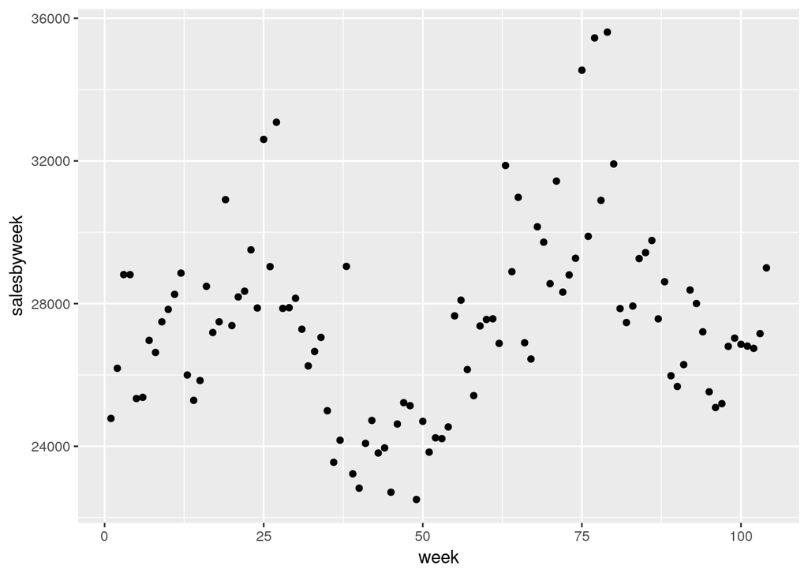

```r
prod_trans %>%
  filter(commodity=="pasta") %>%
  group_by(week) %>%
  summarise(salesbyweek = sum(dollar_sales)) %>%
  ggplot(aes(x=week,y=salesbyweek))+geom_point()
```

From the plot above, it looks like there are trends in sales. There are low sales around week 0 and week 45 and high sales around week 25 and week 75. Sales don’t appear to be decreasing over the given period of time so that shows good health of the category.

## Question F

I wanted to join causal with transactions and run a linear regression on dollar_sales (only for pasta) with feature_desc, display_desc, store #, and brand to see if any of these things are good predictors of sales but data was too large for my computer. Therefore, I looked at some graphs and aggregate summary statistics to see if there was anything else interesting that I could find in the data.

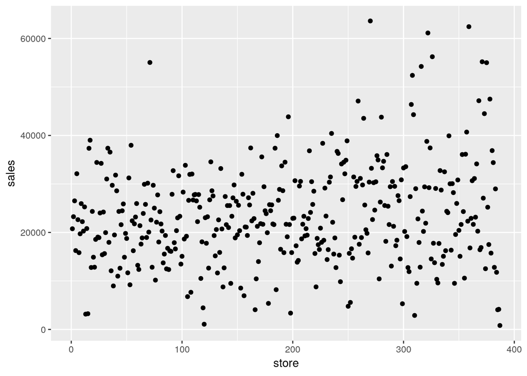

```r
causal$upc <- as.numeric(causal$upc)

transactions %>%
  group_by(store) %>%
  summarise(sales=sum(dollar_sales)) %>%
  ggplot(aes(x=store,y=sales))+geom_point()
```

```r
causal$display_desc <- as.factor(causal$display_desc)

causal %>%
  group_by(store) %>%
  summarise(not_display=sum(display_desc=="Not on Display")) %>%
  arrange(desc(not_display))
```

```
## # A tibble: 381 x 2
##    store not_display
##    <dbl>       <int>
##  1   333        1085
##  2   384        1073
##  3   284        1072
##  4   352        1066
##  5   377        1052
##  6   302         765
##  7   321         764
##  8   329         762
##  9   275         756
## 10   286         754
## # … with 371 more rows
```

```r
causal %>%
  group_by(store) %>%
  summarise(reardisplay=sum(display_desc=="Rear End Cap")) %>%
  arrange(desc(reardisplay))
```

```
## # A tibble: 381 x 2
##    store reardisplay
##    <dbl>       <int>
##  1   126         212
##  2   187         208
##  3    67         204
##  4   214         200
##  5    41         194
##  6   365         192
##  7   124         189
##  8    82         185
##  9   301         185
## 10    65         179
## # … with 371 more rows
```

```r
causal %>%
  group_by(store,display_desc) %>%
  filter(display_desc!="Not on Display") %>%
  summarise(display=n()) %>%
  arrange(desc(display))
```

```
## # A tibble: 2,897 x 3
## # Groups:   store [381]
##    store display_desc               display
##    <dbl> <fct>                        <int>
##  1   270 Mid-Aisle End Cap              506
##  2   187 In-Shelf                       436
##  3   326 Mid-Aisle End Cap              272
##  4   152 In-Shelf                       257
##  5    78 In-Shelf                       246
##  6    93 Secondary Location Display     230
##  7   154 In-Shelf                       229
##  8    99 Mid-Aisle End Cap              228
##  9    73 Secondary Location Display     221
## 10   142 Secondary Location Display     213
## # … with 2,887 more rows
```

Then decided to look at whether mean sales were statistically significantly larger in the non-coupon users category.

```r
pasta_data <- prod_trans %>% filter(commodity=="pasta")
t.test(dollar_sales ~ coupon, data = prod_trans)
```

```
##
##  Welch Two Sample t-test
##
## data:  dollar_sales by coupon
## t = 79.666, df = 94653, p-value < 2.2e-16
## alternative hypothesis: true difference in means is not equal to 0
## 95 percent confidence interval:
##  0.2855150 0.2999181
## sample estimates:
## mean in group 0 mean in group 1
##        1.761703        1.468987
```

```r
t.test(dollar_sales ~ coupon, data = pasta_data)
```

```
##
##  Welch Two Sample t-test
##
## data:  dollar_sales by coupon
## t = 47.191, df = 18716, p-value < 2.2e-16
## alternative hypothesis: true difference in means is not equal to 0
## 95 percent confidence interval:
##  0.3371698 0.3663928
## sample estimates:
## mean in group 0 mean in group 1
##       1.2278890       0.8761077
```